# Chapter 12 Faecal Microbiota Transplantation (FMT)

## 12.1 What is the trend of the microbiota in each type after FMT?

### 12.1.1 Alpha diversity

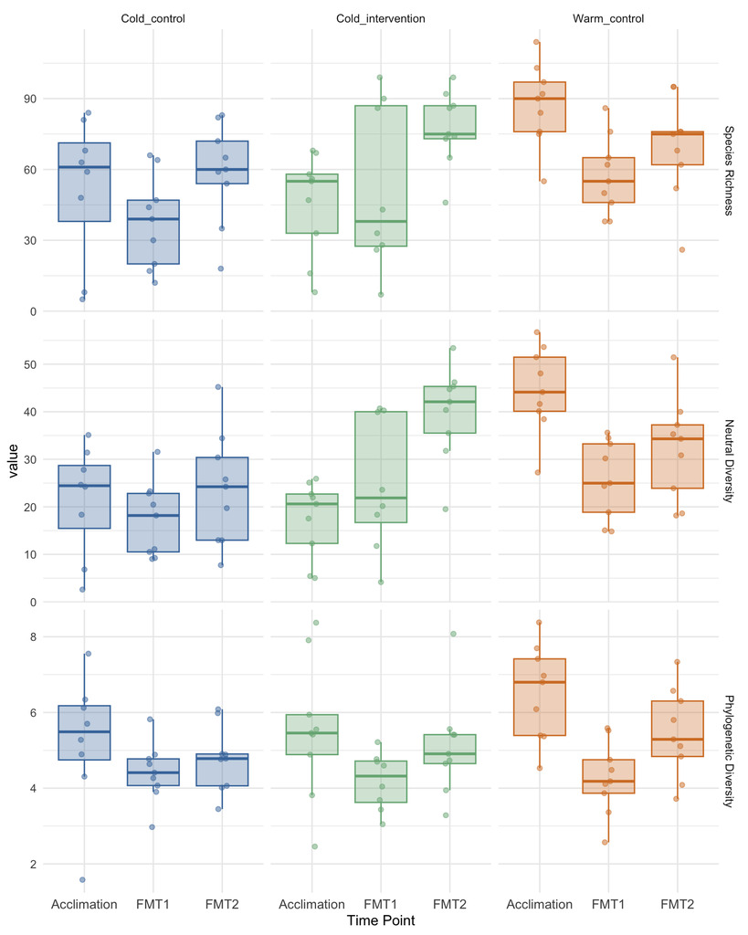

```r
label_map <- c(
  "Control" = "Cold-control",
  "Treatment" = "Cold-intervention",
  "Hot_control" = "Warm-control",
  "richness" = "Species Richness",
  "neutral" = "Neutral Diversity",
  "phylogenetic" = "Phylogenetic Diversity"
)

alpha_div %>%
  pivot_longer(-sample, names_to = "metric", values_to = "value") %>%
  left_join(., sample_metadata, by = join_by(sample == Tube_code)) %>%
  filter(time_point %in% c("FMT1","Acclimation", "FMT2")) %>%
  mutate(metric = factor(metric, levels = c("richness", "neutral", "phylogenetic"))) %>%
  ggplot(aes(y = value, x = time_point, color = type, fill = type)) +
  geom_boxplot(outlier.shape = NA, show.legend = FALSE) +
  geom_point(position = position_jitterdodge(jitter.width = 0.2, dodge.width = 0.8), alpha = 0.5, show.legend = FALSE) +
  facet_grid(metric ~ type, scales = "free_y", labeller = labeller(metric = label_map, type = label_map))+
#  facet_nested(.~metric+type, labeller = labeller(metric = label_map, type = label_map))+
  scale_color_manual(name="Type",
                       breaks=c("Cold_control", "Warm_control", "Cold_intervention"),
                       labels=c("Cold_control", "Warm_control", "Cold_intervention"),
                       values=c("#4477AA","#d57d2c","#76b183")) +
      scale_fill_manual(name="Type",
                       breaks=c("Cold_control", "Warm_control", "Cold_intervention"),
                       labels=c("Cold_control", "Warm_control", "Cold_intervention"),
                       values=c("#4477AA50","#d57d2c50","#76b18350")) +
  theme_minimal() +
  theme(axis.text.x=element_text(size=10))+
  labs(x = "Time Point", y = "value")
```

```r
alpha_div_meta <- alpha_div %>%
  left_join(sample_metadata, by = join_by(sample == Tube_code)) %>%
  filter(time_point=="FMT1"|time_point=="Acclimation"|time_point=="FMT2")
```

#### 12.1.1.1 Richness

```r
Modelq0GLMMNB <- glmer.nb(richness ~ type*time_point+(1|individual), data = alpha_div_meta)
summary(Modelq0GLMMNB)
```

```
Generalized linear mixed model fit by maximum likelihood (Laplace
  Approximation) [glmerMod]
 Family: Negative Binomial(5.7695)  ( log )
Formula: richness ~ type * time_point + (1 | individual)
   Data: alpha_div_meta

      AIC       BIC    logLik -2*log(L)  df.resid
    757.7     783.7    -367.8     735.7        68

Scaled residuals:
     Min       1Q   Median       3Q      Max
-2.01194 -0.49654  0.06198  0.55789  1.90952

Random effects:
 Groups     Name        Variance Std.Dev.
 individual (Intercept) 0.02586  0.1608
Number of obs: 79, groups:  individual, 27

Fixed effects:
                                     Estimate Std. Error z value Pr(>|z|)
(Intercept)                            3.9089     0.1696  23.046   <2e-16 ***
typeCold_intervention                 -0.1233     0.2297  -0.537   0.5916
typeWarm_control                       0.5568     0.2283   2.439   0.0147 *
time_pointFMT1                        -0.3140     0.2167  -1.449   0.1473
time_pointFMT2                         0.1487     0.2173   0.684   0.4937
typeCold_intervention:time_pointFMT1   0.4309     0.3068   1.404   0.1602
typeWarm_control:time_pointFMT1       -0.1155     0.2983  -0.387   0.6986
typeCold_intervention:time_pointFMT2   0.4093     0.2990   1.369   0.1710
typeWarm_control:time_pointFMT2       -0.3876     0.2988  -1.297   0.1945
---
Signif. codes:  0 '***' 0.001 '**' 0.01 '*' 0.05 '.' 0.1 ' ' 1

Correlation of Fixed Effects:
            (Intr) typCl_ typWr_ t_FMT1 t_FMT2 tC_:_FMT1 tW_:_FMT1 tC_:_FMT2
typCld_ntrv -0.721
typWrm_cntr -0.741  0.535
tim_pntFMT1 -0.677  0.497  0.503
tim_pntFMT2 -0.702  0.507  0.520  0.532
typC_:_FMT1  0.482 -0.664 -0.357 -0.707 -0.378
typW_:_FMT1  0.496 -0.362 -0.671 -0.727 -0.389  0.515
typC_:_FMT2  0.498 -0.686 -0.370 -0.384 -0.719  0.511     0.280
typW_:_FMT2  0.515 -0.370 -0.684 -0.388 -0.730  0.276     0.516     0.524
```

```r
emmeans::emmeans(Modelq0GLMMNB, pairwise ~ type)
```

```
$emmeans
 type              emmean     SE  df asymp.LCL asymp.UCL
 Cold_control        3.85 0.1050 Inf      3.65      4.06
 Cold_intervention   4.01 0.1030 Inf      3.81      4.21
 Warm_control        4.24 0.0996 Inf      4.05      4.44

Results are averaged over the levels of: time_point
Results are given on the log (not the response) scale.
Confidence level used: 0.95

$contrasts
 contrast                         estimate    SE  df z.ratio p.value
 Cold_control - Cold_intervention   -0.157 0.145 Inf  -1.083  0.5246
 Cold_control - Warm_control        -0.389 0.144 Inf  -2.711  0.0184
 Cold_intervention - Warm_control   -0.232 0.143 Inf  -1.627  0.2342

Results are averaged over the levels of: time_point
Results are given on the log (not the response) scale.
P value adjustment: tukey method for comparing a family of 3 estimates
```

```r
emmeans::emmeans(Modelq0GLMMNB, pairwise ~ time_point)
```

```
$emmeans
 time_point  emmean     SE  df asymp.LCL asymp.UCL
 Acclimation   4.05 0.0938 Inf      3.87      4.24
 FMT1          3.84 0.0949 Inf      3.66      4.03
 FMT2          4.21 0.0895 Inf      4.03      4.38

Results are averaged over the levels of: type
Results are given on the log (not the response) scale.
Confidence level used: 0.95

$contrasts
 contrast           estimate    SE  df z.ratio p.value
 Acclimation - FMT1    0.209 0.123 Inf   1.700  0.2050
 Acclimation - FMT2   -0.156 0.121 Inf  -1.286  0.4028
 FMT1 - FMT2          -0.365 0.122 Inf  -2.997  0.0077

Results are averaged over the levels of: type
Results are given on the log (not the response) scale.
P value adjustment: tukey method for comparing a family of 3 estimates
```

#### 12.1.1.2 Neutral

```r
Modelq1n <- nlme::lme(neutral ~ type*time_point,
               random = ~ 1 | individual,
               data = alpha_div_meta)
summary(Modelq1n)
```

```
Linear mixed-effects model fit by REML
  Data: alpha_div_meta
       AIC      BIC    logLik
  563.2664 587.9998 -270.6332

Random effects:
 Formula: ~1 | individual
        (Intercept) Residual
StdDev:    4.551076 9.160157

Fixed effects:  neutral ~ type * time_point
                                          Value Std.Error DF   t-value p-value
(Intercept)                           21.343055  3.603126 46  5.923483  0.0000
typeCold_intervention                 -3.944072  4.960549 24 -0.795088  0.4344
typeWarm_control                      23.258307  4.960549 24  4.688656  0.0001
time_pointFMT1                        -3.983722  4.472618 46 -0.890691  0.3777
time_pointFMT2                         2.374489  4.472618 46  0.530895  0.5980
typeCold_intervention:time_pointFMT1  11.253000  6.325237 46  1.779064  0.0818
typeWarm_control:time_pointFMT1      -14.877819  6.216964 46 -2.393101  0.0208
typeCold_intervention:time_pointFMT2  20.108022  6.216964 46  3.234380  0.0023
typeWarm_control:time_pointFMT2      -14.775497  6.216964 46 -2.376642  0.0217
 Correlation:
                                     (Intr) typCl_ typWr_ t_FMT1 t_FMT2
typeCold_intervention                -0.726
typeWarm_control                     -0.726  0.528
time_pointFMT1                       -0.663  0.481  0.481
time_pointFMT2                       -0.663  0.481  0.481  0.534
typeCold_intervention:time_pointFMT1  0.469 -0.638 -0.340 -0.707 -0.378
typeWarm_control:time_pointFMT1       0.477 -0.346 -0.649 -0.719 -0.384
typeCold_intervention:time_pointFMT2  0.477 -0.649 -0.346 -0.384 -0.719
typeWarm_control:time_pointFMT2       0.477 -0.346 -0.649 -0.384 -0.719
                                     tC_:_FMT1 tW_:_FMT1 tC_:_FMT2
typeCold_intervention
typeWarm_control
time_pointFMT1
time_pointFMT2
typeCold_intervention:time_pointFMT1
typeWarm_control:time_pointFMT1       0.509
typeCold_intervention:time_pointFMT2  0.509     0.276
typeWarm_control:time_pointFMT2       0.272     0.518     0.518

Standardized Within-Group Residuals:
       Min         Q1        Med         Q3        Max
-2.1324340 -0.7088533  0.0456110  0.6569569  1.9681295

Number of Observations: 79
Number of Groups: 27
```

```r
emmeans::emmeans(Modelq1n, pairwise ~ type)
```

```
$emmeans
 type              emmean   SE df lower.CL upper.CL
 Cold_control        20.8 2.36 26     16.0     25.7
 Cold_intervention   27.3 2.36 24     22.4     32.2
 Warm_control        34.2 2.33 24     29.4     39.0

Results are averaged over the levels of: time_point
Degrees-of-freedom method: containment
Confidence level used: 0.95

$contrasts
 contrast                         estimate   SE df t.ratio p.value
 Cold_control - Cold_intervention    -6.51 3.33 24  -1.952  0.1461
 Cold_control - Warm_control        -13.37 3.31 24  -4.038  0.0013
 Cold_intervention - Warm_control    -6.86 3.31 24  -2.073  0.1170

Results are averaged over the levels of: time_point
Degrees-of-freedom method: containment
P value adjustment: tukey method for comparing a family of 3 estimates
```

```r
emmeans::emmeans(Modelq1n, pairwise ~ time_point)
```

```
$emmeans
 time_point  emmean   SE df lower.CL upper.CL
 Acclimation   27.8 2.01 24     23.6     31.9
 FMT1          22.6 2.01 24     18.4     26.7
 FMT2          31.9 1.97 24     27.9     36.0

Results are averaged over the levels of: type
Degrees-of-freedom method: containment
Confidence level used: 0.95

$contrasts
 contrast           estimate   SE df t.ratio p.value
 Acclimation - FMT1     5.19 2.55 46   2.034  0.1156
 Acclimation - FMT2    -4.15 2.52 46  -1.646  0.2372
 FMT1 - FMT2           -9.34 2.52 46  -3.703  0.0016

Results are averaged over the levels of: type
Degrees-of-freedom method: containment
P value adjustment: tukey method for comparing a family of 3 estimates
```

#### 12.1.1.3 Phylogenetic

```r
Model_phylo <- nlme::lme(phylogenetic ~ type*time_point,
               random = ~ 1 | individual,
               data = alpha_div_meta)
summary(Model_phylo)
```

```
Linear mixed-effects model fit by REML
  Data: alpha_div_meta
      AIC      BIC   logLik
  269.592 294.3254 -123.796

Random effects:
 Formula: ~1 | individual
        (Intercept) Residual
StdDev:   0.4979037 1.144231

Fixed effects:  phylogenetic ~ type * time_point
                                         Value Std.Error DF   t-value p-value
(Intercept)                           5.250918 0.4401145 46 11.930799  0.0000
typeCold_intervention                 0.283251 0.6055741 24  0.467740  0.6442
typeWarm_control                      1.264508 0.6055741 24  2.088114  0.0476
time_pointFMT1                       -0.835721 0.5582377 46 -1.497070  0.1412
time_pointFMT2                       -0.480730 0.5582377 46 -0.861157  0.3936
typeCold_intervention:time_pointFMT1 -0.545026 0.7894673 46 -0.690371  0.4934
typeWarm_control:time_pointFMT1      -1.408920 0.7762583 46 -1.815014  0.0760
typeCold_intervention:time_pointFMT2  0.056014 0.7762583 46  0.072159  0.9428
typeWarm_control:time_pointFMT2      -0.584302 0.7762583 46 -0.752716  0.4555
 Correlation:
                                     (Intr) typCl_ typWr_ t_FMT1 t_FMT2
typeCold_intervention                -0.727
typeWarm_control                     -0.727  0.528
time_pointFMT1                       -0.676  0.492  0.492
time_pointFMT2                       -0.676  0.492  0.492  0.533
typeCold_intervention:time_pointFMT1  0.478 -0.652 -0.348 -0.707 -0.377
typeWarm_control:time_pointFMT1       0.486 -0.353 -0.663 -0.719 -0.383
typeCold_intervention:time_pointFMT2  0.486 -0.663 -0.353 -0.383 -0.719
typeWarm_control:time_pointFMT2       0.486 -0.353 -0.663 -0.383 -0.719
                                     tC_:_FMT1 tW_:_FMT1 tC_:_FMT2
typeCold_intervention
typeWarm_control
time_pointFMT1
time_pointFMT2
typeCold_intervention:time_pointFMT1
typeWarm_control:time_pointFMT1       0.509
typeCold_intervention:time_pointFMT2  0.509     0.276
typeWarm_control:time_pointFMT2       0.271     0.517     0.517

Standardized Within-Group Residuals:
        Min          Q1         Med          Q3         Max
-2.81770682 -0.52006818 -0.06472395  0.55839915  2.23601869

Number of Observations: 79
Number of Groups: 27
```

```r
emmeans::emmeans(Model_phylo, pairwise ~ type)
```

```
$emmeans
 type              emmean    SE df lower.CL upper.CL
 Cold_control        4.81 0.280 26     4.24     5.39
 Cold_intervention   4.93 0.280 24     4.35     5.51
 Warm_control        5.41 0.276 24     4.84     5.98

Results are averaged over the levels of: time_point
Degrees-of-freedom method: containment
Confidence level used: 0.95

$contrasts
 contrast                         estimate    SE df t.ratio p.value
 Cold_control - Cold_intervention    -0.12 0.396 24  -0.304  0.9505
 Cold_control - Warm_control         -0.60 0.393 24  -1.527  0.2963
 Cold_intervention - Warm_control    -0.48 0.393 24  -1.221  0.4525

Results are averaged over the levels of: time_point
Degrees-of-freedom method: containment
P value adjustment: tukey method for comparing a family of 3 estimates
```

```r
emmeans::emmeans(Model_phylo, pairwise ~ time_point)
```

```
$emmeans
 time_point  emmean    SE df lower.CL upper.CL
 Acclimation   5.77 0.245 24     5.26     6.27
 FMT1          4.28 0.245 24     3.77     4.79
 FMT2          5.11 0.240 24     4.61     5.61

Results are averaged over the levels of: type
Degrees-of-freedom method: containment
Confidence level used: 0.95

$contrasts
 contrast           estimate    SE df t.ratio p.value
 Acclimation - FMT1    1.487 0.319 46   4.666 <0.0001
 Acclimation - FMT2    0.657 0.315 46   2.085  0.1042
 FMT1 - FMT2          -0.830 0.315 46  -2.635  0.0302

Results are averaged over the levels of: type
Degrees-of-freedom method: containment
P value adjustment: tukey method for comparing a family of 3 estimates
```

#### 12.1.1.4 Pairwise comparisons between time-points within each group

Post-hoc contrasts of the neutral diversity model (Tukey-adjusted p-values), used for the brackets in Figure 3a of the manuscript.

```r
emmeans::emmeans(Modelq1n, pairwise ~ time_point | type, adjust = "tukey")$contrasts
```

```
type = Cold_control:
 contrast           estimate   SE df t.ratio p.value
 Acclimation - FMT1     3.98 4.47 46   0.891  0.6489
 Acclimation - FMT2    -2.37 4.47 46  -0.531  0.8566
 FMT1 - FMT2           -6.36 4.32 46  -1.472  0.3134

type = Cold_intervention:
 contrast           estimate   SE df t.ratio p.value
 Acclimation - FMT1    -7.27 4.47 46  -1.625  0.2454
 Acclimation - FMT2   -22.48 4.32 46  -5.207 <0.0001
 FMT1 - FMT2          -15.21 4.47 46  -3.401  0.0039

type = Warm_control:
 contrast           estimate   SE df t.ratio p.value
 Acclimation - FMT1    18.86 4.32 46   4.368  0.0002
 Acclimation - FMT2    12.40 4.32 46   2.872  0.0166
 FMT1 - FMT2           -6.46 4.32 46  -1.496  0.3022

Degrees-of-freedom method: containment
P value adjustment: tukey method for comparing a family of 3 estimates
```

#### 12.1.1.5 Between-group contrasts at each time-point (Supplementary Table S8)

Estimated marginal means of the neutral diversity model (`Modelq1n`), compared between groups within each time-point, with Tukey adjustment over the three contrasts of each time-point. Groups in the data are `Cold_control` (CC, Control in the figure script), `Cold_intervention` (CI, Treatment) and `Warm_control` (WC, Hot_control). The table reports first minus second group in the order CC, CI, WC (CC - WC, CI - WC, CI - CC), i.e. the sign of the CC - CI contrast returned by `pairs()` is reversed. The last row is the unadjusted contrast between cold-intervention at FMT2 and warm-control at acclimation.

```r
emm_type_time <- emmeans::emmeans(Modelq1n, ~ type | time_point)
table_S8 <- as.data.frame(pairs(emm_type_time, adjust = "tukey")) %>%
  mutate(flip = contrast == "Cold_control - Cold_intervention",
         estimate = ifelse(flip, -estimate, estimate),
         t.ratio = ifelse(flip, -t.ratio, t.ratio),
         contrast = recode(contrast,
                           "Cold_control - Warm_control" = "CC - WC",
                           "Cold_intervention - Warm_control" = "CI - WC",
                           "Cold_control - Cold_intervention" = "CI - CC")) %>%
  select(time_point, contrast, estimate, SE, df, t.ratio, p.value) %>%
  arrange(factor(time_point, levels = c("Acclimation", "FMT1", "FMT2")),
          factor(contrast, levels = c("CC - WC", "CI - WC", "CI - CC")))

emm_all <- emmeans::emmeans(Modelq1n, ~ type * time_point)
emm_grid <- as.data.frame(emm_all)
w <- as.numeric(emm_grid$type == "Cold_intervention" & emm_grid$time_point == "FMT2") -
     as.numeric(emm_grid$type == "Warm_control" & emm_grid$time_point == "Acclimation")
last_row <- as.data.frame(emmeans::contrast(emm_all, list("CI(FMT2) - WC(Acclimation)" = w), adjust = "none")) %>%
  transmute(time_point = "FMT2 (CI) vs Acclimation (WC)", contrast, estimate, SE, df, t.ratio, p.value)

bind_rows(table_S8, last_row) %>%
  mutate(across(c(estimate, SE, t.ratio), ~ round(., 2)),
         p.value = signif(p.value, 3)) %>%
  tt()
```

| time_point | contrast | estimate | SE | df | t.ratio | p.value |
| --- | --- | --- | --- | --- | --- | --- |
| Acclimation | CC - WC | -23.26 | 4.96 | 24 | -4.69 | 0.000262 |
| Acclimation | CI - WC | -27.20 | 4.82 | 24 | -5.64 | 0.000024 |
| Acclimation | CI - CC | -3.94 | 4.96 | 24 | -0.80 | 0.710000 |
| FMT1 | CC - WC | -8.38 | 4.82 | 24 | -1.74 | 0.212000 |
| FMT1 | CI - WC | -1.07 | 4.96 | 24 | -0.22 | 0.975000 |
| FMT1 | CI - CC | 7.31 | 4.96 | 24 | 1.47 | 0.321000 |
| FMT2 | CC - WC | -8.48 | 4.82 | 24 | -1.76 | 0.205000 |
| FMT2 | CI - WC | 7.68 | 4.82 | 24 | 1.59 | 0.268000 |
| FMT2 | CI - CC | 16.16 | 4.82 | 24 | 3.35 | 0.007200 |
| FMT2 (CI) vs Acclimation (WC) | CI(FMT2) - WC(Acclimation) | -4.72 | 4.82 | 24 | -0.98 | 0.337000 |

### 12.1.2 Beta diversity

#### 12.1.2.1 Number of samples used

```r
samples_to_keep_post7 <- sample_metadata %>%
  filter(time_point=="FMT1"|time_point=="Acclimation"|time_point=="FMT2") %>%
  select(Tube_code) %>%
  pull()
subset_meta_post7 <- sample_metadata %>%
  filter(time_point=="FMT1"|time_point=="Acclimation"|time_point=="FMT2")

subset_meta_post7$time_point<-as.factor(subset_meta_post7$time_point)
subset_meta_post7$type<-as.factor(subset_meta_post7$type)
length(samples_to_keep_post7)
```

```
[1] 79
```

#### 12.1.2.2 Repeated-measures tests (same individuals at Acclimation, FMT1 and FMT2)

The legacy `adonis2(d ~ type*time_point, strata = individual)` calls below cannot test the between-individual `type` term and their within-individual permutations of raw data are anti-conservative for the interaction. The manuscript instead reports (i) the type x time_point interaction with a distance-based Freedman-Lane test (residuals of the reduced model `~ type + time_point` permuted within individual; the adonis2 R2 of the interaction is reported alongside) and (ii) the between-individual `type` effect with a whole-plot test (group labels permuted across individuals).

```r
# Euclidean embedding of a distance matrix (all positive eigenvalues of the Gower-centred matrix)
fl_embed <- function(d) {
  pc <- suppressWarnings(cmdscale(d, k = attr(d, "Size") - 1, eig = TRUE))  # warning: non-Euclidean distances, negative eigenvalues dropped
  pc$points[, pc$eig[seq_len(ncol(pc$points))] > 1e-8, drop = FALSE]
}
# Residual sum of squares of Y after projecting on design X (QR based)
fl_rss <- function(Y, X) { q <- qr(X); sum(qr.resid(q, Y)^2) }

# (a) Distance-based Freedman-Lane test of the type x time_point interaction.
# d: dist; meta: data frame with Tube_code, type, time_point, individual (matched to labels(d) by Tube_code).
# Returns pseudo-F, partial R2 (SS_interaction / SS_total) and the permutation p value.
fl_interaction_test <- function(d, meta, nperm = 9999) {
  meta <- as.data.frame(meta)[match(labels(d), meta$Tube_code), ]
  meta$type <- factor(meta$type); meta$time_point <- factor(meta$time_point)
  Y <- fl_embed(d); n <- nrow(Y)
  X0 <- model.matrix(~ type + time_point, meta)
  X1 <- model.matrix(~ type * time_point, meta)
  Fstat <- function(Yp) {
    r0 <- fl_rss(Yp, X0); r1 <- fl_rss(Yp, X1)
    ((r0 - r1) / (ncol(X1) - ncol(X0))) / (r1 / (n - ncol(X1)))
  }
  q0 <- qr(X0); fit0 <- qr.fitted(q0, Y); res0 <- qr.resid(q0, Y)
  F_obs <- Fstat(Y)
  ss_tot <- sum(scale(Y, scale = FALSE)^2)
  R2 <- (fl_rss(Y, X0) - fl_rss(Y, X1)) / ss_tot
  set.seed(123)
  ctrl <- how(within = Within(type = "free"),
              plots = Plots(strata = factor(meta$individual), type = "none"), nperm = nperm)
  perms <- shuffleSet(n, nperm, control = ctrl)
  Fp <- apply(perms, 1, function(p) Fstat(fit0 + res0[p, , drop = FALSE]))
  tibble(test = "Freedman-Lane type x time_point (within-individual)", n = n,
         F = F_obs, R2_partial = R2, p = (1 + sum(Fp >= F_obs - 1e-12)) / (1 + nperm))
}

# (b) Whole-plot test of the between-individual `type` effect after time_point:
# individuals' group labels are permuted across individuals (each individual keeps its time points).
wholeplot_type_test <- function(d, meta, nperm = 9999) {
  meta <- as.data.frame(meta)[match(labels(d), meta$Tube_code), ]
  meta$type <- factor(meta$type); meta$time_point <- factor(meta$time_point)
  Y <- fl_embed(d); n <- nrow(Y)
  ind <- factor(meta$individual)
  ind_type <- meta$type[match(levels(ind), meta$individual)]
  Xt <- model.matrix(~ time_point, meta)
  Fty <- function(tp) {
    ty <- tp[as.integer(ind)]
    X1 <- cbind(Xt, model.matrix(~ ty)[, -1, drop = FALSE])
    r0 <- fl_rss(Y, Xt); r1 <- fl_rss(Y, X1)
    ((r0 - r1) / (ncol(X1) - ncol(Xt))) / (r1 / (n - ncol(X1)))
  }
  F_obs <- Fty(ind_type)
  set.seed(123)
  Fp <- replicate(nperm, Fty(sample(ind_type)))
  tibble(test = "Whole-plot type (after time_point)", n = n, n_individuals = nlevels(ind),
         F = F_obs, p = (1 + sum(Fp >= F_obs - 1e-12)) / (1 + nperm))
}
```

#### 12.1.2.3 Richness

```r
richness_post7 <- as.matrix(beta_q0n$S)
richness_post7 <- as.dist(richness_post7[rownames(richness_post7) %in% samples_to_keep_post7,
               colnames(richness_post7) %in% samples_to_keep_post7])
set.seed(123)
betadisper(richness_post7, subset_meta_post7$type[match(labels(richness_post7), subset_meta_post7$Tube_code)]) %>% permutest(., pairwise = TRUE, permutations = 9999)
```

```
Permutation test for homogeneity of multivariate dispersions
Permutation: free
Number of permutations: 9999

Response: Distances
          Df  Sum Sq  Mean Sq      F N.Perm Pr(>F)
Groups     2 0.06454 0.032268 4.9753   9999 0.0096 **
Residuals 76 0.49290 0.006485
---
Signif. codes:  0 '***' 0.001 '**' 0.01 '*' 0.05 '.' 0.1 ' ' 1

Pairwise comparisons:
(Observed p-value below diagonal, permuted p-value above diagonal)
                  Cold_control Cold_intervention Warm_control
Cold_control                           0.6825000       0.0125
Cold_intervention    0.6817089                         0.0030
Warm_control         0.0119513         0.0035106
```

```r
# LEGACY (not reported): adonis2 with strata = individual cannot test the between-individual `type` term and is anti-conservative for the interaction.
# Use omnibus_group_by_time (Freedman-Lane interaction + whole-plot type test) below.
set.seed(123)
adonis2(richness_post7 ~ type*time_point,
        data = subset_meta_post7 %>% arrange(match(Tube_code,labels(richness_post7))),
        permutations = 9999,
        strata = subset_meta_post7 %>% arrange(match(Tube_code,labels(richness_post7))) %>% pull(individual),
        by="terms") %>%
        broom::tidy() %>%
        tt()
```

| term | df | SumOfSqs | R2 | statistic | p.value |
| --- | --- | --- | --- | --- | --- |
| type | 2 | 3.120806 | 0.11961754 | 5.546155 | 1e-04 |
| time_point | 2 | 1.703776 | 0.06530413 | 3.027874 | 1e-04 |
| type:time_point | 4 | 1.570884 | 0.06021051 | 1.395852 | 2e-04 |
| Residual | 70 | 19.694403 | 0.75486782 | NA | NA |
| Total | 78 | 26.089870 | 1.00000000 | NA | NA |

#### 12.1.2.4 Neutral

```r
neutral_post7 <- as.matrix(beta_q1n$S)
neutral_post7 <- as.dist(neutral_post7[rownames(neutral_post7) %in% samples_to_keep_post7,
               colnames(neutral_post7) %in% samples_to_keep_post7])
set.seed(123)
betadisper(neutral_post7, subset_meta_post7$type[match(labels(neutral_post7), subset_meta_post7$Tube_code)]) %>% permutest(., pairwise = TRUE, permutations = 9999)
```

```
Permutation test for homogeneity of multivariate dispersions
Permutation: free
Number of permutations: 9999

Response: Distances
          Df  Sum Sq  Mean Sq      F N.Perm Pr(>F)
Groups     2 0.06738 0.033689 3.8309   9999  0.027 *
Residuals 76 0.66833 0.008794
---
Signif. codes:  0 '***' 0.001 '**' 0.01 '*' 0.05 '.' 0.1 ' ' 1

Pairwise comparisons:
(Observed p-value below diagonal, permuted p-value above diagonal)
                  Cold_control Cold_intervention Warm_control
Cold_control                           0.1628000       0.1958
Cold_intervention    0.1611083                         0.0066
Warm_control         0.1985046         0.0069718
```

```r
# LEGACY (not reported): adonis2 with strata = individual cannot test the between-individual `type` term and is anti-conservative for the interaction.
# Use omnibus_group_by_time (Freedman-Lane interaction + whole-plot type test) below.
set.seed(123)
adonis2(neutral_post7 ~ type*time_point,
        data = subset_meta_post7 %>% arrange(match(Tube_code,labels(neutral_post7))),
        permutations = 9999,
        strata = subset_meta_post7 %>% arrange(match(Tube_code,labels(neutral_post7))) %>% pull(individual),
        by="terms") %>%
        broom::tidy() %>%
        tt()
```

| term | df | SumOfSqs | R2 | statistic | p.value |
| --- | --- | --- | --- | --- | --- |
| type | 2 | 3.705559 | 0.14953528 | 7.609355 | 1e-04 |
| time_point | 2 | 2.217656 | 0.08949199 | 4.553951 | 1e-04 |
| type:time_point | 4 | 1.813192 | 0.07317011 | 1.861693 | 3e-04 |
| Residual | 70 | 17.044094 | 0.68780262 | NA | NA |
| Total | 78 | 24.780501 | 1.00000000 | NA | NA |

#### 12.1.2.5 Phylogenetic

```r
phylo_post7 <- as.matrix(beta_q1p$S)
phylo_post7 <- as.dist(phylo_post7[rownames(phylo_post7) %in% samples_to_keep_post7,
               colnames(phylo_post7) %in% samples_to_keep_post7])
set.seed(123)
betadisper(phylo_post7, subset_meta_post7$type[match(labels(phylo_post7), subset_meta_post7$Tube_code)]) %>% permutest(., pairwise = TRUE, permutations = 9999)
```

```
Permutation test for homogeneity of multivariate dispersions
Permutation: free
Number of permutations: 9999

Response: Distances
          Df  Sum Sq  Mean Sq      F N.Perm Pr(>F)
Groups     2 0.05438 0.027192 2.1499   9999 0.1255
Residuals 76 0.96123 0.012648

Pairwise comparisons:
(Observed p-value below diagonal, permuted p-value above diagonal)
                  Cold_control Cold_intervention Warm_control
Cold_control                            0.164500       0.7061
Cold_intervention     0.155309                         0.0867
Warm_control          0.697512          0.083221
```

```r
# LEGACY (not reported): adonis2 with strata = individual cannot test the between-individual `type` term and is anti-conservative for the interaction.
# Use omnibus_group_by_time (Freedman-Lane interaction + whole-plot type test) below.
set.seed(123)
adonis2(phylo_post7 ~ type*time_point,
        data = subset_meta_post7 %>% arrange(match(Tube_code,labels(phylo_post7))),
        permutations = 9999,
        strata = subset_meta_post7 %>% arrange(match(Tube_code,labels(phylo_post7))) %>% pull(individual),
          by="terms") %>%
        broom::tidy() %>%
        tt()
```

| term | df | SumOfSqs | R2 | statistic | p.value |
| --- | --- | --- | --- | --- | --- |
| type | 2 | 0.2941494 | 0.07500331 | 3.592254 | 0.0001 |
| time_point | 2 | 0.5528857 | 0.14097687 | 6.752032 | 0.0001 |
| type:time_point | 4 | 0.2088312 | 0.05324856 | 1.275159 | 0.1482 |
| Residual | 70 | 2.8659522 | 0.73077126 | NA | NA |
| Total | 78 | 3.9218184 | 1.00000000 | NA | NA |

#### 12.1.2.6 Group x time (Freedman-Lane) and group (whole-plot) tests: reported in the manuscript

```r
omni_dist <- list(Richness = richness_post7, Neutral = neutral_post7, Phylogenetic = phylo_post7)
omni_meta <- subset_meta_post7
# adonis2 R2 of the interaction (legacy chunks above, same value; no strata needed for R2)
omni_res <- imap_dfr(omni_dist, function(d, m) {
  md <- omni_meta %>% arrange(match(Tube_code, labels(d)))
  a <- adonis2(d ~ type * time_point, data = md, permutations = 0, by = "terms")
  bind_rows(
    fl_interaction_test(d, omni_meta, nperm = 9999) %>%
      mutate(adonis2_R2_interaction = a$R2[3]),
    wholeplot_type_test(d, omni_meta, nperm = 9999)) %>%
    mutate(metric = m, .before = 1)
})
omni_res %>% mutate(across(where(is.numeric), ~ signif(., 4))) %>% tt()
```

| metric | test | n | F | R2_partial | p | adonis2_R2_interaction | n_individuals |
| --- | --- | --- | --- | --- | --- | --- | --- |
| Richness | Freedman-Lane type x time_point (within-individual) | 79 | 1.396 | 0.06023 | 0.0001 | 0.06021 | NA |
| Richness | Whole-plot type (after time_point) | 79 | 5.444 | NA | 0.0001 | NA | 27 |
| Neutral | Freedman-Lane type x time_point (within-individual) | 79 | 1.804 | 0.07187 | 0.0001 | 0.07317 | NA |
| Neutral | Whole-plot type (after time_point) | 79 | 7.022 | NA | 0.0001 | NA | 27 |
| Phylogenetic | Freedman-Lane type x time_point (within-individual) | 79 | 1.191 | 0.05180 | 0.0801 | 0.05325 | NA |
| Phylogenetic | Whole-plot type (after time_point) | 79 | 2.993 | NA | 0.0105 | NA | 27 |

#### 12.1.2.7 dbRDA

```r
#Richness
cca_ord <- capscale(formula = richness_post7 ~ subset_meta_post7$time_point* subset_meta_post7$type)
CAP_df <- as.data.frame(vegan::scores(cca_ord, display = "sites")) %>%
  rownames_to_column('Tube_code') %>%
  left_join(subset_meta_post7, by = 'Tube_code') %>%
  column_to_rownames('Tube_code')%>%
  mutate(x_cen = mean(CAP1, na.rm = TRUE)) %>%
  mutate(y_cen = mean(CAP2, na.rm = TRUE))

biplot_scores <- as.data.frame(vegan::scores(cca_ord, display = "bp")) %>%
  rownames_to_column("Variable")
biplot_scores$Variable <- recode(biplot_scores$Variable,
                                 "subset_meta_post7$time_pointFMT1" = "FMT1",
                                 "subset_meta_post7$time_pointFMT2"="FMT2",
                                 "subset_meta_post7$typeHot_control"="Warm-control",
                                 "subset_meta_post7$typeTreatment" = "Cold-intervention",
                                 "subset_meta_post7$time_pointFMT1:subset_meta_post7$typeHot_control"="FMT1 Warm-control",
                                 "subset_meta_post7$time_pointFMT2:subset_meta_post7$typeHot_control"="FMT2 Warm-control",
                                 "subset_meta_post7$time_pointFMT1:subset_meta_post7$typeTreatment" = "FMT1 Cold-intervention",
                                 "subset_meta_post7$time_pointFMT2:subset_meta_post7$typeTreatment" = "FMT2 Cold-intervention")

beta_richness_nmds_post7 <-CAP_df %>%
  group_by(type, time_point) %>%
  mutate(x_cen = mean(CAP1, na.rm = TRUE)) %>%
  mutate(y_cen = mean(CAP2, na.rm = TRUE)) %>%
  ungroup() %>%
  ggplot(., aes(x=CAP1,y=CAP2, color=type,shape = time_point)) +
  scale_color_manual(name="Type",
          breaks=c("Cold_control", "Warm_control", "Cold_intervention"),
          labels=c("Cold-control","Warm-control", "Cold-intervention"),
          values=c("#4477AA","#d57d2c", "#76b183")) +
      scale_fill_manual(name="Type",
          breaks=c("Cold_control", "Warm_control", "Cold_intervention"),
          labels=c("Cold-control","Warm-control", "Cold-intervention"),
          values=c("#4477AA50","#d57d2c50","#76b18350")) +
        scale_x_discrete(labels = c("Control" = "Cold-Cold", "Hot_control" = "Hot-Hot", "Treatment" = "Cold-Hot")) +
  geom_point(size=2) +
  geom_hline(yintercept = 0, linetype = "dotted") +
  geom_vline(xintercept = 0, linetype = "dotted") +
  geom_segment(aes(x=x_cen, y=y_cen, xend=CAP1, yend=CAP2), alpha=0.2) +
  geom_segment(data = biplot_scores, aes(x = 0, y = 0, xend = CAP1, yend = CAP2),
               inherit.aes = FALSE, arrow = arrow(length = unit(0.2, "cm")), color = "black") +
  geom_text(data = biplot_scores, aes(x = CAP1, y = CAP2, label = Variable),
            inherit.aes = FALSE, color = "black", vjust = -0.5, hjust = 0.5)+
  theme_classic()

#Neutral
cca_ord <- capscale(formula = neutral_post7 ~ subset_meta_post7$time_point* subset_meta_post7$type)
CAP_df <- as.data.frame(vegan::scores(cca_ord, display = "sites")) %>%
  rownames_to_column('Tube_code') %>%
  left_join(subset_meta_post7, by = 'Tube_code') %>%
  column_to_rownames('Tube_code')%>%
  mutate(x_cen = mean(CAP1, na.rm = TRUE)) %>%
  mutate(y_cen = mean(CAP2, na.rm = TRUE))

biplot_scores <- as.data.frame(vegan::scores(cca_ord, display = "bp")) %>%
  rownames_to_column("Variable")
biplot_scores$Variable <- recode(biplot_scores$Variable,
                                 "subset_meta_post7$time_pointFMT1" = "FMT1",
                                 "subset_meta_post7$time_pointFMT2"="FMT2",
                                 "subset_meta_post7$typeHot_control"="Warm-control",
                                 "subset_meta_post7$typeTreatment" = "Cold-intervention",
                                 "subset_meta_post7$time_pointFMT1:subset_meta_post7$typeHot_control"="FMT1 Warm-control",
                                 "subset_meta_post7$time_pointFMT2:subset_meta_post7$typeHot_control"="FMT2 Warm-control",
                                 "subset_meta_post7$time_pointFMT1:subset_meta_post7$typeTreatment" = "FMT1 Cold-intervention",
                                 "subset_meta_post7$time_pointFMT2:subset_meta_post7$typeTreatment" = "FMT2 Cold-intervention")

beta_neutral_nmds_post7 <- CAP_df %>%
  group_by(type, time_point) %>%
  mutate(x_cen = mean(CAP1, na.rm = TRUE)) %>%
  mutate(y_cen = mean(CAP2, na.rm = TRUE)) %>%
  ungroup() %>%
  ggplot(., aes(x=CAP1,y=CAP2, color=type,shape = time_point)) +
  scale_color_manual(name="Type",
          breaks=c("Cold_control", "Warm_control", "Cold_intervention"),
          labels=c("Cold-control","Warm-control", "Cold-intervention"),
          values=c("#4477AA","#d57d2c", "#76b183")) +
      scale_fill_manual(name="Type",
          breaks=c("Cold_control", "Warm_control", "Cold_intervention"),
          labels=c("Cold-control","Warm-control", "Cold-intervention"),
          values=c("#4477AA50","#d57d2c50","#76b18350")) +
        scale_x_discrete(labels = c("Control" = "Cold-Cold", "Hot_control" = "Hot-Hot", "Treatment" = "Cold-Hot")) +
  geom_point(size=2) +
  geom_hline(yintercept = 0, linetype = "dotted") +
  geom_vline(xintercept = 0, linetype = "dotted") +
  geom_segment(aes(x=x_cen, y=y_cen, xend=CAP1, yend=CAP2), alpha=0.2) +
  geom_segment(data = biplot_scores, aes(x = 0, y = 0, xend = CAP1, yend = CAP2),
               inherit.aes = FALSE, arrow = arrow(length = unit(0.2, "cm")), color = "black") +
  geom_text(data = biplot_scores, aes(x = CAP1, y = CAP2, label = Variable),
            inherit.aes = FALSE, color = "black", vjust = -0.5, hjust = 0.5)+
  theme_classic()


#Phylogenetic
cca_ord <- capscale(formula = phylo_post7 ~ subset_meta_post7$time_point* subset_meta_post7$type)
CAP_df <- as.data.frame(vegan::scores(cca_ord, display = "sites")) %>%
  rownames_to_column('Tube_code') %>%
  left_join(subset_meta_post7, by = 'Tube_code') %>%
  column_to_rownames('Tube_code')%>%
  mutate(x_cen = mean(CAP1, na.rm = TRUE)) %>%
  mutate(y_cen = mean(CAP2, na.rm = TRUE))

biplot_scores <- as.data.frame(vegan::scores(cca_ord, display = "bp")) %>%
  rownames_to_column("Variable")
biplot_scores$Variable <- recode(biplot_scores$Variable,
                                 "subset_meta_post7$time_pointFMT1" = "FMT1",
                                 "subset_meta_post7$time_pointFMT2"="FMT2",
                                 "subset_meta_post7$typeHot_control"="Warm-control",
                                 "subset_meta_post7$typeTreatment" = "Cold-intervention",
                                 "subset_meta_post7$time_pointFMT1:subset_meta_post7$typeHot_control"="FMT1 Warm-control",
                                 "subset_meta_post7$time_pointFMT2:subset_meta_post7$typeHot_control"="FMT2 Warm-control",
                                 "subset_meta_post7$time_pointFMT1:subset_meta_post7$typeTreatment" = "FMT1 Cold-intervention",
                                 "subset_meta_post7$time_pointFMT2:subset_meta_post7$typeTreatment" = "FMT2 Cold-intervention")

beta_phylogenetic_nmds_post7 <- CAP_df %>%
  group_by(type, time_point) %>%
  mutate(x_cen = mean(CAP1, na.rm = TRUE)) %>%
  mutate(y_cen = mean(CAP2, na.rm = TRUE)) %>%
  ungroup() %>%
  ggplot(., aes(x=CAP1,y=CAP2, color=type,shape = time_point)) +
  scale_color_manual(name="Type",
          breaks=c("Cold_control", "Warm_control", "Cold_intervention"),
          labels=c("Cold-control","Warm-control", "Cold-intervention"),
          values=c("#4477AA","#d57d2c", "#76b183")) +
      scale_fill_manual(name="Type",
          breaks=c("Cold_control", "Warm_control", "Cold_intervention"),
          labels=c("Cold-control","Warm-control", "Cold-intervention"),
          values=c("#4477AA50","#d57d2c50","#76b18350")) +
        scale_x_discrete(labels = c("Control" = "Cold-Cold", "Hot_control" = "Hot-Hot", "Treatment" = "Cold-Hot")) +
  geom_point(size=2) +
  geom_hline(yintercept = 0, linetype = "dotted") +
  geom_vline(xintercept = 0, linetype = "dotted") +
  geom_segment(aes(x=x_cen, y=y_cen, xend=CAP1, yend=CAP2), alpha=0.2) +
  geom_segment(data = biplot_scores, aes(x = 0, y = 0, xend = CAP1, yend = CAP2),
               inherit.aes = FALSE, arrow = arrow(length = unit(0.2, "cm")), color = "black") +
  geom_text(data = biplot_scores, aes(x = CAP1, y = CAP2, label = Variable),
            inherit.aes = FALSE, color = "black", vjust = -0.5, hjust = 0.5)+
  theme_classic()
```

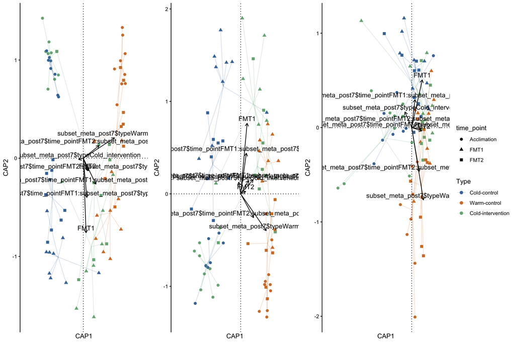

```r
ggarrange(beta_richness_nmds_post7, beta_neutral_nmds_post7, beta_phylogenetic_nmds_post7, ncol=3, nrow=1, common.legend = TRUE, legend="right")
```

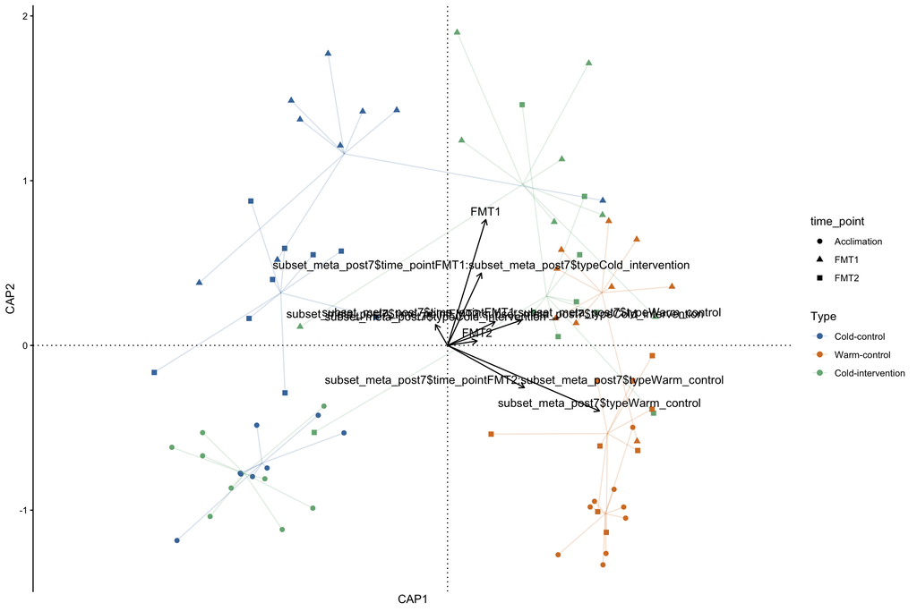

```r
beta_neutral_nmds_post7
```

#### 12.1.2.8 Centroid trajectories (Figure 3b)

Group centroids are the mean dbRDA site scores of each experimental group at each time-point. In the manuscript figure the centroids are numbered (1, Acclimation; 2, FMT1; 3, FMT2) and joined by curved arrows that show the trajectory of each group.

```r
cca_neutral <- capscale(neutral_post7 ~ time_point * type,
                        data = subset_meta_post7 %>% arrange(match(Tube_code, labels(neutral_post7))))
vegan::scores(cca_neutral, display = "sites") %>%
  as.data.frame() %>%
  rownames_to_column("Tube_code") %>%
  left_join(subset_meta_post7, by = "Tube_code") %>%
  group_by(type, time_point) %>%
  summarise(CAP1 = mean(CAP1), CAP2 = mean(CAP2), n = n(), .groups = "drop") %>%
  tt()
```

| type | time_point | CAP1 | CAP2 | n |
| --- | --- | --- | --- | --- |
| Cold_control | Acclimation | -0.9182178 | -0.7150201 | 8 |
| Cold_control | FMT1 | -0.5113170 | 1.1632694 | 9 |
| Cold_control | FMT2 | -0.8257081 | 0.3190689 | 9 |
| Cold_intervention | Acclimation | -1.0042938 | -0.7784012 | 9 |
| Cold_intervention | FMT1 | 0.3720847 | 0.9769864 | 8 |
| Cold_intervention | FMT2 | 0.4901159 | 0.2997881 | 9 |
| Warm_control | Acclimation | 0.7811747 | -1.0214914 | 9 |
| Warm_control | FMT1 | 0.7638144 | 0.3194742 | 9 |
| Warm_control | FMT2 | 0.7916656 | -0.5345670 | 9 |

#### 12.1.2.9 Manuscript Figure 3

Panels a and b of Figure 3 are drawn by `manuscript_figures/figure3/make_panels.R` (composed and exported with `manuscript_figures/figure3/build_figure3.py`), using the colour scheme of Figure 1.

```r
source("manuscript_figures/figure3/make_panels.R")
```

[figure not shown]

## 12.2 Differences between acclimation and FMT1 across the three experimental groups

### 12.2.1 Beta diversity

#### 12.2.1.1 CI from acclimation to FMT1

```r
samples_to_keep <- sample_metadata %>%
  filter(time_point %in% c("FMT1","Acclimation") & type == "Cold_intervention") %>%
  select(Tube_code) %>%
  pull()
subset_meta <- sample_metadata %>%
  filter(time_point %in% c("FMT1","Acclimation") & type == "Cold_intervention")

length(samples_to_keep)
```

```
[1] 17
```

```r
richness <- as.matrix(beta_q0n$S)
richness <- as.dist(richness[rownames(richness) %in% samples_to_keep,
               colnames(richness) %in% samples_to_keep])
set.seed(123)
betadisper(richness, subset_meta$time_point[match(labels(richness), subset_meta$Tube_code)]) %>% permutest(., pairwise = TRUE, permutations = 9999)
```

```
Permutation test for homogeneity of multivariate dispersions
Permutation: free
Number of permutations: 9999

Response: Distances
          Df   Sum Sq   Mean Sq     F N.Perm Pr(>F)
Groups     1 0.001206 0.0012057 0.125   9999  0.711
Residuals 15 0.144707 0.0096471

Pairwise comparisons:
(Observed p-value below diagonal, permuted p-value above diagonal)
            Acclimation   FMT1
Acclimation             0.7161
FMT1            0.72862
```

```r
set.seed(123)
adonis2(richness ~ time_point,
        data = subset_meta %>% arrange(match(Tube_code,labels(richness))),
        permutations = 9999,
        strata = subset_meta %>% arrange(match(Tube_code,labels(richness))) %>% pull(individual),
        by="terms") %>%
        broom::tidy() %>%
        tt()
```

| term | df | SumOfSqs | R2 | statistic | p.value |
| --- | --- | --- | --- | --- | --- |
| time_point | 1 | 0.9551308 | 0.1632291 | 2.926054 | 0.00390625 |
| Residual | 15 | 4.8963429 | 0.8367709 | NA | NA |
| Total | 16 | 5.8514737 | 1.0000000 | NA | NA |

```r
neutral <- as.matrix(beta_q1n$S)
neutral <- as.dist(neutral[rownames(neutral) %in% samples_to_keep,
               colnames(neutral) %in% samples_to_keep])
set.seed(123)
betadisper(neutral, subset_meta$time_point[match(labels(neutral), subset_meta$Tube_code)]) %>% permutest(., pairwise = TRUE, permutations = 9999)
```

```
Permutation test for homogeneity of multivariate dispersions
Permutation: free
Number of permutations: 9999

Response: Distances
          Df   Sum Sq  Mean Sq      F N.Perm Pr(>F)
Groups     1 0.004394 0.004394 0.2999   9999    0.6
Residuals 15 0.219796 0.014653

Pairwise comparisons:
(Observed p-value below diagonal, permuted p-value above diagonal)
            Acclimation   FMT1
Acclimation             0.5909
FMT1            0.59202
```

```r
set.seed(123)
adonis2(neutral ~ time_point,
        data = subset_meta %>% arrange(match(Tube_code,labels(neutral))),
        permutations = 9999,
        strata = subset_meta %>% arrange(match(Tube_code,labels(neutral))) %>% pull(individual),
        by="terms") %>%
        broom::tidy() %>%
        tt()
```

| term | df | SumOfSqs | R2 | statistic | p.value |
| --- | --- | --- | --- | --- | --- |
| time_point | 1 | 1.312777 | 0.2358567 | 4.629826 | 0.00390625 |
| Residual | 15 | 4.253219 | 0.7641433 | NA | NA |
| Total | 16 | 5.565996 | 1.0000000 | NA | NA |

```r
phylo <- as.matrix(beta_q1p$S)
phylo <- as.dist(phylo[rownames(phylo) %in% samples_to_keep,
               colnames(phylo) %in% samples_to_keep])
set.seed(123)
betadisper(phylo, subset_meta$time_point[match(labels(phylo), subset_meta$Tube_code)]) %>% permutest(., pairwise = TRUE, permutations = 9999)
```

```
Permutation test for homogeneity of multivariate dispersions
Permutation: free
Number of permutations: 9999

Response: Distances
          Df  Sum Sq  Mean Sq      F N.Perm Pr(>F)
Groups     1 0.02219 0.022191 0.8144   9999 0.3864
Residuals 15 0.40871 0.027247

Pairwise comparisons:
(Observed p-value below diagonal, permuted p-value above diagonal)
            Acclimation   FMT1
Acclimation             0.3746
FMT1            0.38108
```

```r
set.seed(123)
adonis2(phylo ~ time_point,
        data = subset_meta %>% arrange(match(Tube_code,labels(phylo))),
        permutations = 9999,
        strata = subset_meta %>% arrange(match(Tube_code,labels(phylo))) %>% pull(individual),
        by="terms") %>%
        tt()
```

| Df | SumOfSqs | R2 | F | Pr(>F) |
| --- | --- | --- | --- | --- |
| 1 | 0.2531943 | 0.1791546 | 3.273842 | 0.03125 |
| 15 | 1.1600785 | 0.8208454 | NA | NA |
| 16 | 1.4132728 | 1.0000000 | NA | NA |

#### 12.2.1.2 CC from acclimation to FMT1

```r
samples_to_keep <- sample_metadata %>%
  filter(time_point %in% c("FMT1","Acclimation") & type == "Cold_control") %>%
  select(Tube_code) %>%
  pull()
subset_meta <- sample_metadata %>%
  filter(time_point %in% c("FMT1","Acclimation") & type == "Cold_control")

length(samples_to_keep)
```

```
[1] 17
```

```r
richness <- as.matrix(beta_q0n$S)
richness <- as.dist(richness[rownames(richness) %in% samples_to_keep,
               colnames(richness) %in% samples_to_keep])
set.seed(123)
betadisper(richness, subset_meta$time_point[match(labels(richness), subset_meta$Tube_code)]) %>% permutest(., pairwise = TRUE, permutations = 9999)
```

```
Permutation test for homogeneity of multivariate dispersions
Permutation: free
Number of permutations: 9999

Response: Distances
          Df   Sum Sq   Mean Sq      F N.Perm Pr(>F)
Groups     1 0.002321 0.0023205 0.2591   9999 0.6199
Residuals 15 0.134317 0.0089544

Pairwise comparisons:
(Observed p-value below diagonal, permuted p-value above diagonal)
            Acclimation   FMT1
Acclimation             0.6169
FMT1            0.61811
```

```r
set.seed(123)
adonis2(richness ~ time_point,
        data = subset_meta %>% arrange(match(Tube_code,labels(richness))),
        permutations = 9999,
        strata = subset_meta %>% arrange(match(Tube_code,labels(richness))) %>% pull(individual),
        by="terms") %>%
        broom::tidy() %>%
        tt()
```

| term | df | SumOfSqs | R2 | statistic | p.value |
| --- | --- | --- | --- | --- | --- |
| time_point | 1 | 0.6804988 | 0.1228384 | 2.100611 | 0.00390625 |
| Residual | 15 | 4.8592912 | 0.8771616 | NA | NA |
| Total | 16 | 5.5397900 | 1.0000000 | NA | NA |

```r
neutral <- as.matrix(beta_q1n$S)
neutral <- as.dist(neutral[rownames(neutral) %in% samples_to_keep,
               colnames(neutral) %in% samples_to_keep])
set.seed(123)
betadisper(neutral, subset_meta$time_point[match(labels(neutral), subset_meta$Tube_code)]) %>% permutest(., pairwise = TRUE, permutations = 9999)
```

```
Permutation test for homogeneity of multivariate dispersions
Permutation: free
Number of permutations: 9999

Response: Distances
          Df   Sum Sq   Mean Sq      F N.Perm Pr(>F)
Groups     1 0.002521 0.0025206 0.1629   9999 0.7043
Residuals 15 0.232162 0.0154775

Pairwise comparisons:
(Observed p-value below diagonal, permuted p-value above diagonal)
            Acclimation   FMT1
Acclimation             0.6975
FMT1            0.69223
```

```r
set.seed(123)
adonis2(neutral ~ time_point,
        data = subset_meta %>% arrange(match(Tube_code,labels(neutral))),
        permutations = 9999,
        strata = subset_meta %>% arrange(match(Tube_code,labels(neutral))) %>% pull(individual),
        by="terms") %>%
        broom::tidy() %>%
        tt()
```

| term | df | SumOfSqs | R2 | statistic | p.value |
| --- | --- | --- | --- | --- | --- |
| time_point | 1 | 0.8153894 | 0.1711361 | 3.09706 | 0.00390625 |
| Residual | 15 | 3.9491774 | 0.8288639 | NA | NA |
| Total | 16 | 4.7645668 | 1.0000000 | NA | NA |

```r
phylo <- as.matrix(beta_q1p$S)
phylo <- as.dist(phylo[rownames(phylo) %in% samples_to_keep,
               colnames(phylo) %in% samples_to_keep])
set.seed(123)
betadisper(phylo, subset_meta$time_point[match(labels(phylo), subset_meta$Tube_code)]) %>% permutest(., pairwise = TRUE, permutations = 9999)
```

```
Permutation test for homogeneity of multivariate dispersions
Permutation: free
Number of permutations: 9999

Response: Distances
          Df   Sum Sq   Mean Sq      F N.Perm Pr(>F)
Groups     1 0.002284 0.0022841 0.2022   9999 0.6582
Residuals 15 0.169443 0.0112962

Pairwise comparisons:
(Observed p-value below diagonal, permuted p-value above diagonal)
            Acclimation   FMT1
Acclimation             0.6587
FMT1            0.65938
```

```r
set.seed(123)
adonis2(phylo ~ time_point,
        data = subset_meta %>% arrange(match(Tube_code,labels(phylo))),
        permutations = 9999,
        strata = subset_meta %>% arrange(match(Tube_code,labels(phylo))) %>% pull(individual),
        by="terms") %>%
        tt()
```

| Df | SumOfSqs | R2 | F | Pr(>F) |
| --- | --- | --- | --- | --- |
| 1 | 0.1176029 | 0.1666113 | 2.998803 | 0.015625 |
| 15 | 0.5882490 | 0.8333887 | NA | NA |
| 16 | 0.7058519 | 1.0000000 | NA | NA |

#### 12.2.1.3 WC from acclimation to FMT1

```r
samples_to_keep <- sample_metadata %>%
  filter(time_point %in% c("FMT1","Acclimation") & type == "Warm_control") %>%
  select(Tube_code) %>%
  pull()
subset_meta <- sample_metadata %>%
  filter(time_point %in% c("FMT1","Acclimation") & type == "Warm_control")

length(samples_to_keep)
```

```
[1] 18
```

```r
richness <- as.matrix(beta_q0n$S)
richness <- as.dist(richness[rownames(richness) %in% samples_to_keep,
               colnames(richness) %in% samples_to_keep])
set.seed(123)
betadisper(richness, subset_meta$time_point[match(labels(richness), subset_meta$Tube_code)]) %>% permutest(., pairwise = TRUE, permutations = 9999)
```

```
Permutation test for homogeneity of multivariate dispersions
Permutation: free
Number of permutations: 9999

Response: Distances
          Df   Sum Sq   Mean Sq      F N.Perm Pr(>F)
Groups     1 0.022023 0.0220227 14.458   9999 0.0024 **
Residuals 16 0.024371 0.0015232
---
Signif. codes:  0 '***' 0.001 '**' 0.01 '*' 0.05 '.' 0.1 ' ' 1

Pairwise comparisons:
(Observed p-value below diagonal, permuted p-value above diagonal)
            Acclimation   FMT1
Acclimation             0.0021
FMT1          0.0015647
```

```r
set.seed(123)
adonis2(richness ~ time_point,
        data = subset_meta %>% arrange(match(Tube_code,labels(richness))),
        permutations = 9999,
        strata = subset_meta %>% arrange(match(Tube_code,labels(richness))) %>% pull(individual),
        by="terms") %>%
        broom::tidy() %>%
        tt()
```

| term | df | SumOfSqs | R2 | statistic | p.value |
| --- | --- | --- | --- | --- | --- |
| time_point | 1 | 0.5796135 | 0.132397 | 2.441615 | 0.00390625 |
| Residual | 16 | 3.7982306 | 0.867603 | NA | NA |
| Total | 17 | 4.3778441 | 1.000000 | NA | NA |

```r
neutral <- as.matrix(beta_q1n$S)
neutral <- as.dist(neutral[rownames(neutral) %in% samples_to_keep,
               colnames(neutral) %in% samples_to_keep])
set.seed(123)
betadisper(neutral, subset_meta$time_point[match(labels(neutral), subset_meta$Tube_code)]) %>% permutest(., pairwise = TRUE, permutations = 9999)
```

```
Permutation test for homogeneity of multivariate dispersions
Permutation: free
Number of permutations: 9999

Response: Distances
          Df   Sum Sq   Mean Sq      F N.Perm Pr(>F)
Groups     1 0.014589 0.0145888 2.6594   9999 0.1265
Residuals 16 0.087771 0.0054857

Pairwise comparisons:
(Observed p-value below diagonal, permuted p-value above diagonal)
            Acclimation   FMT1
Acclimation             0.1303
FMT1            0.12246
```

```r
set.seed(123)
adonis2(neutral ~ time_point,
        data = subset_meta %>% arrange(match(Tube_code,labels(neutral))),
        permutations = 9999,
        strata = subset_meta %>% arrange(match(Tube_code,labels(neutral))) %>% pull(individual),
        by="terms") %>%
        broom::tidy() %>%
        tt()
```

| term | df | SumOfSqs | R2 | statistic | p.value |
| --- | --- | --- | --- | --- | --- |
| time_point | 1 | 0.6954835 | 0.1707749 | 3.295123 | 0.00390625 |
| Residual | 16 | 3.3770315 | 0.8292251 | NA | NA |
| Total | 17 | 4.0725150 | 1.0000000 | NA | NA |

```r
phylo <- as.matrix(beta_q1p$S)
phylo <- as.dist(phylo[rownames(phylo) %in% samples_to_keep,
               colnames(phylo) %in% samples_to_keep])
set.seed(123)
betadisper(phylo, subset_meta$time_point[match(labels(phylo), subset_meta$Tube_code)]) %>% permutest(., pairwise = TRUE, permutations = 9999)
```

```
Permutation test for homogeneity of multivariate dispersions
Permutation: free
Number of permutations: 9999

Response: Distances
          Df   Sum Sq   Mean Sq      F N.Perm Pr(>F)
Groups     1 0.001463 0.0014625 0.1701   9999 0.8248
Residuals 16 0.137566 0.0085979

Pairwise comparisons:
(Observed p-value below diagonal, permuted p-value above diagonal)
            Acclimation  FMT1
Acclimation             0.851
FMT1            0.68549
```

```r
set.seed(123)
adonis2(phylo ~ time_point,
        data = subset_meta %>% arrange(match(Tube_code,labels(phylo))),
        permutations = 9999,
        strata = subset_meta %>% arrange(match(Tube_code,labels(phylo))) %>% pull(individual),
        by="terms") %>%
        tt()
```

| Df | SumOfSqs | R2 | F | Pr(>F) |
| --- | --- | --- | --- | --- |
| 1 | 0.0925260 | 0.1571182 | 2.982496 | 0.01953125 |
| 16 | 0.4963682 | 0.8428818 | NA | NA |
| 17 | 0.5888942 | 1.0000000 | NA | NA |

### 12.2.2 Functional differences

### 12.2.3 Paired functional-trait tests (same individuals)

```r
# Paired Wilcoxon signed-rank test per trait, pairing by individual (only individuals with both time points),
# same trait filtering as the unpaired chunks (samples with any non-zero trait, traits with sum > 0 within the group and time points),
# Benjamini-Hochberg across traits within each contrast.
# Unpaired counts (wilcox.test(value ~ time_point) + BH) are shown for comparison: exploratory, they treat samples as independent.
paired_trait_test <- function(ty, tp_a, tp_b) {
  long <- element_gift %>%
    filter(time_point %in% c(tp_a, tp_b) & type == ty) %>%
    select(-time_point, -type) %>%
    filter(rowSums(across(where(is.numeric), ~ . != 0)) > 0) %>%
    select(Tube_code, where(~ is.numeric(.) && sum(.) > 0)) %>%
    left_join(sample_metadata[c("Tube_code", "time_point", "individual")], by = "Tube_code") %>%
    pivot_longer(-c(Tube_code, time_point, individual), names_to = "trait", values_to = "value")
  pu <- long %>% group_by(trait) %>%
    summarise(p = wilcox.test(value ~ time_point)$p.value, .groups = "drop") %>%
    mutate(p_adj = p.adjust(p, "BH"))
  w <- long %>% select(-Tube_code) %>%
    pivot_wider(names_from = time_point, values_from = value, values_fn = mean) %>%
    filter(!is.na(.data[[tp_a]]), !is.na(.data[[tp_b]]))
  n_pairs <- n_distinct(w$individual)
  pp <- w %>% group_by(trait) %>%
    summarise(p = tryCatch(wilcox.test(.data[[tp_a]], .data[[tp_b]], paired = TRUE, exact = FALSE)$p.value,
                           error = function(e) NA_real_), .groups = "drop") %>%
    mutate(p_adj = p.adjust(p, "BH"))
  tibble(contrast = paste0(c(Cold_control = "CC", Cold_intervention = "CI", Warm_control = "WC")[[ty]], ": ", tp_a, " vs ", tp_b),
         n_paired = n_pairs,
         n_sig_paired_BH = sum(pp$p_adj < 0.05, na.rm = TRUE),
         min_p_paired = min(pp$p, na.rm = TRUE),
         min_p_adj_paired = min(pp$p_adj, na.rm = TRUE),
         min_attainable_exact_p = 2 / 2^n_pairs,
         n_sig_unpaired_BH_exploratory = sum(pu$p_adj < 0.05, na.rm = TRUE))
}
paired_trait_results <- bind_rows(
  map_dfr(c("Cold_control", "Cold_intervention", "Warm_control"), paired_trait_test, tp_a = "Acclimation", tp_b = "FMT1"),
  map_dfr(c("Cold_control", "Cold_intervention", "Warm_control"), paired_trait_test, tp_a = "FMT1", tp_b = "FMT2"))
paired_trait_results %>% mutate(across(where(is.numeric) & !c(n_paired, n_sig_paired_BH, n_sig_unpaired_BH_exploratory), ~ signif(., 3))) %>% tt()
```

| contrast | n_paired | n_sig_paired_BH | min_p_paired | min_p_adj_paired | min_attainable_exact_p | n_sig_unpaired_BH_exploratory |
| --- | --- | --- | --- | --- | --- | --- |
| CC: Acclimation vs FMT1 | 8 | 0 | 0.01430 | 0.207 | 0.00781 | 11 |
| CI: Acclimation vs FMT1 | 8 | 0 | 0.01430 | 0.155 | 0.00781 | 2 |
| WC: Acclimation vs FMT1 | 9 | 0 | 0.00915 | 0.249 | 0.00391 | 0 |
| CC: FMT1 vs FMT2 | 9 | 0 | 0.00915 | 0.213 | 0.00391 | 0 |
| CI: FMT1 vs FMT2 | 8 | 0 | 0.01430 | 0.460 | 0.00781 | 0 |
| WC: FMT1 vs FMT2 | 9 | 0 | 0.00915 | 0.244 | 0.00391 | 0 |

#### 12.2.3.1 CI from acclimation to FMT1

*Exploratory: the unpaired rank-sum tests and plots in this section treat samples as independent (see `paired_trait_tests_acc_fmt1` above for the paired tests).*

```r
significant_element<-element_gift %>%
  filter(time_point %in% c("FMT1","Acclimation") & type == "Cold_intervention") %>%
  select(-time_point, -type) %>%
  filter(rowSums(across(where(is.numeric), ~ . != 0)) > 0) %>%
  select(Tube_code, where( ~ is.numeric(.) && sum(.) > 0)) %>%
  left_join(sample_metadata[c("Tube_code", "time_point")], by = "Tube_code") %>%
  pivot_longer(-c(Tube_code, time_point),
               names_to = "trait",
               values_to = "value") %>%
  group_by(trait) %>%
  summarise(p_value = wilcox.test(value ~ time_point)$p.value) %>%
  mutate(p_adjust = p.adjust(p_value, method = "BH")) %>%
  filter(p_adjust < 0.05) %>%
  remove_rownames() %>%
  left_join(., uniqueGIFT_db, by=join_by("trait"=="Code_element"))
```

```r
element_gift_sig <- element_gift %>%
  select(Tube_code, all_of(intersect(
    significant_element$trait,
    colnames(element_gift)
  ))) %>%
  left_join(., sample_metadata[c("Tube_code", "type", "time_point")], by = join_by(Tube_code == Tube_code)) %>%
  filter(time_point %in% c("FMT1","Acclimation"))%>%
  filter(type=="Cold_intervention")

difference_table <- element_gift_sig %>%
  select(-Tube_code, -type) %>%
  group_by(time_point) %>%
  summarise(across(everything(), mean)) %>%
  t() %>%
  row_to_names(row_number = 1) %>%
  as.data.frame() %>%
  mutate_if(is.character, as.numeric) %>%
  rownames_to_column(., "Elements") %>%
  left_join(.,uniqueGIFT_db[c(1,3,4)],by = join_by(Elements == Code_element)) %>%
  arrange(Function) %>%
  mutate(Difference=Acclimation-FMT1)%>%
  mutate(group_color = ifelse(Difference <0,"FMT1", "Acclimation"))
```

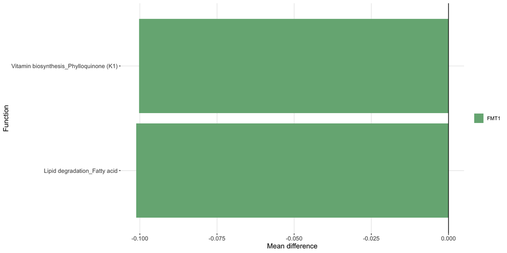

```r
difference_table %>%
  ggplot(aes(x=forcats::fct_reorder(Function,Difference), y=Difference, fill=group_color)) +
  geom_col() +
  scale_fill_manual(values=c("#76b183",'#008080')) +
  geom_hline(yintercept=0) +
  coord_flip()+
  theme(axis.text = element_text(size = 10),
        axis.title = element_text(size = 12),
        legend.position = "right",
        legend.title = element_blank(),
        panel.background = element_blank(),
        panel.grid.major = element_line(size = 0.15, linetype = 'solid',
                                        colour = "grey"))+
  xlab("Function") +
  ylab("Mean difference")
```

#### 12.2.3.2 CC from acclimation to FMT1

```r
significant_element<-element_gift %>%
  filter(time_point %in% c("FMT1","Acclimation") & type == "Cold_control") %>%
  select(-time_point, -type) %>%
  filter(rowSums(across(where(is.numeric), ~ . != 0)) > 0) %>%
  select(Tube_code, where( ~ is.numeric(.) && sum(.) > 0)) %>%
  left_join(sample_metadata[c("Tube_code", "time_point")], by = "Tube_code") %>%
  pivot_longer(-c(Tube_code, time_point),
               names_to = "trait",
               values_to = "value") %>%
  group_by(trait) %>%
  summarise(p_value = wilcox.test(value ~ time_point)$p.value) %>%
  mutate(p_adjust = p.adjust(p_value, method = "BH")) %>%
  filter(p_adjust < 0.05) %>%
  remove_rownames() %>%
  left_join(., uniqueGIFT_db, by=join_by("trait"=="Code_element"))
```

```r
element_gift_sig <- element_gift %>%
  select(Tube_code, all_of(intersect(
    significant_element$trait,
    colnames(element_gift)
  ))) %>%
  left_join(., sample_metadata[c("Tube_code", "type", "time_point")], by = join_by(Tube_code == Tube_code)) %>%
  filter(time_point %in% c("FMT1","Acclimation"))%>%
  filter(type=="Cold_control")

difference_table <- element_gift_sig %>%
  select(-Tube_code, -type) %>%
  group_by(time_point) %>%
  summarise(across(everything(), mean)) %>%
  t() %>%
  row_to_names(row_number = 1) %>%
  as.data.frame() %>%
  mutate_if(is.character, as.numeric) %>%
  rownames_to_column(., "Elements") %>%
  left_join(.,uniqueGIFT_db[c(1,3,4)],by = join_by(Elements == Code_element)) %>%
  arrange(Function) %>%
  mutate(Difference=Acclimation-FMT1)%>%
  mutate(group_color = ifelse(Difference <0,"FMT1", "Acclimation"))
```

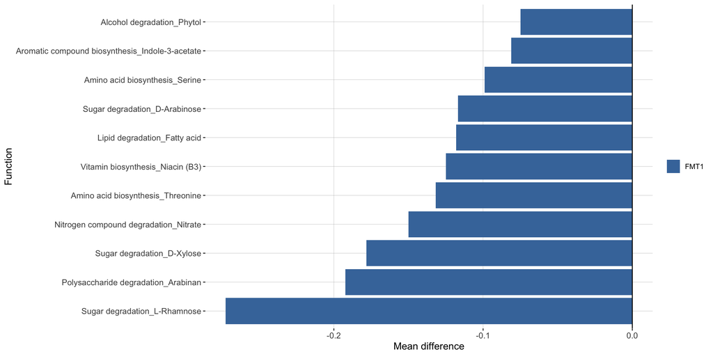

```r
difference_table %>%
  ggplot(aes(x=forcats::fct_reorder(Function,Difference), y=Difference, fill=group_color)) +
  geom_col() +
  scale_fill_manual(values=c("#4477AA",'#008080')) +
  geom_hline(yintercept=0) +
  coord_flip()+
  theme(axis.text = element_text(size = 10),
        axis.title = element_text(size = 12),
        legend.position = "right",
        legend.title = element_blank(),
        panel.background = element_blank(),
        panel.grid.major = element_line(size = 0.15, linetype = 'solid',
                                        colour = "grey"))+
  xlab("Function") +
  ylab("Mean difference")
```

#### 12.2.3.3 WC from acclimation to FMT1

```r
element_gift %>%
  filter(time_point %in% c("FMT1","Acclimation") & type == "Warm_control") %>%
  select(-time_point, -type) %>%
  filter(rowSums(across(where(is.numeric), ~ . != 0)) > 0) %>%
  select(Tube_code, where( ~ is.numeric(.) && sum(.) > 0)) %>%
  left_join(sample_metadata[c("Tube_code", "time_point")], by = "Tube_code") %>%
  pivot_longer(-c(Tube_code, time_point),
               names_to = "trait",
               values_to = "value") %>%
  group_by(trait) %>%
  summarise(p_value = wilcox.test(value ~ time_point)$p.value) %>%
  mutate(p_adjust = p.adjust(p_value, method = "BH")) %>%
  filter(p_adjust < 0.05) %>%
  remove_rownames() %>%
  left_join(., uniqueGIFT_db, by=join_by("trait"=="Code_element"))
```

```
# A tibble: 0 × 7
# ℹ 7 variables: trait <chr>, p_value <dbl>, p_adjust <dbl>,
#   Code_function <chr>, Domain <chr>, Function <chr>, Element <chr>
```

## 12.3 Differences between FMT1 and FMT2 across the three experimental groups

### 12.3.1 Functional differences

*Exploratory: the unpaired rank-sum tests and plots below treat samples as independent; paired FMT1 vs FMT2 tests are in `paired_trait_tests_acc_fmt1`.*

#### 12.3.1.1 CI from FMT1 to FMT2

```r
significant_element<-element_gift %>%
  filter(time_point %in% c("FMT2","FMT1") & type == "Cold_intervention") %>%
  select(-time_point, -type) %>%
  filter(rowSums(across(where(is.numeric), ~ . != 0)) > 0) %>%
  select(Tube_code, where( ~ is.numeric(.) && sum(.) > 0)) %>%
  left_join(sample_metadata[c("Tube_code", "time_point")], by = "Tube_code") %>%
  pivot_longer(-c(Tube_code, time_point),
               names_to = "trait",
               values_to = "value") %>%
  group_by(trait) %>%
  summarise(p_value = wilcox.test(value ~ time_point)$p.value) %>%
  mutate(p_adjust = p.adjust(p_value, method = "BH")) %>%
  filter(p_adjust < 0.05) %>%
  remove_rownames() %>%
  left_join(., uniqueGIFT_db, by=join_by("trait"=="Code_element"))
```

```r
element_gift_sig <- element_gift %>%
  select(Tube_code, all_of(intersect(
    significant_element$trait,
    colnames(element_gift)
  ))) %>%
  left_join(., sample_metadata[c("Tube_code", "type", "time_point")], by = join_by(Tube_code == Tube_code)) %>%
  filter(time_point %in% c("FMT2","FMT1"))%>%
  filter(type=="Cold_intervention")

difference_table <- element_gift_sig %>%
  select(-Tube_code, -type) %>%
  group_by(time_point) %>%
  summarise(across(everything(), mean)) %>%
  t() %>%
  row_to_names(row_number = 1) %>%
  as.data.frame() %>%
  mutate_if(is.character, as.numeric) %>%
  rownames_to_column(., "Elements") %>%
  left_join(.,uniqueGIFT_db[c(1,3,4)],by = join_by(Elements == Code_element)) %>%
  arrange(Function) %>%
  mutate(Difference=FMT1-FMT2)%>%
  mutate(group_color = ifelse(Difference <0,"FMT2", "FMT1"))
```

[figure not shown]

```r
difference_table %>%
  ggplot(aes(x=forcats::fct_reorder(Function,Difference), y=Difference, fill=group_color)) +
  geom_col() +
  scale_fill_manual(values=c('#008080',"#76b183")) +
  geom_hline(yintercept=0) +
  coord_flip()+
  theme(axis.text = element_text(size = 10),
        axis.title = element_text(size = 12),
        legend.position = "right",
        legend.title = element_blank(),
        panel.background = element_blank(),
        panel.grid.major = element_line(size = 0.15, linetype = 'solid',
                                        colour = "grey"))+
  xlab("Function") +
  ylab("Mean difference")
```

#### 12.3.1.2 CC from FMT1 to FMT2

```r
element_gift %>%
  filter(time_point %in% c("FMT2","FMT1") & type == "Cold_control") %>%
  select(-time_point, -type) %>%
  filter(rowSums(across(where(is.numeric), ~ . != 0)) > 0) %>%
  select(Tube_code, where( ~ is.numeric(.) && sum(.) > 0)) %>%
  left_join(sample_metadata[c("Tube_code", "time_point")], by = "Tube_code") %>%
  pivot_longer(-c(Tube_code, time_point),
               names_to = "trait",
               values_to = "value") %>%
  group_by(trait) %>%
  summarise(p_value = wilcox.test(value ~ time_point)$p.value) %>%
  mutate(p_adjust = p.adjust(p_value, method = "BH")) %>%
  filter(p_adjust < 0.05) %>%
  remove_rownames() %>%
  left_join(., uniqueGIFT_db, by=join_by("trait"=="Code_element"))
```

```
# A tibble: 0 × 7
# ℹ 7 variables: trait <chr>, p_value <dbl>, p_adjust <dbl>,
#   Code_function <chr>, Domain <chr>, Function <chr>, Element <chr>
```

#### 12.3.1.3 WC from FMT1 to FMT2

```r
element_gift %>%
  filter(time_point %in% c("FMT2","FMT1") & type == "Warm_control") %>%
  select(-time_point, -type) %>%
  filter(rowSums(across(where(is.numeric), ~ . != 0)) > 0) %>%
  select(Tube_code, where( ~ is.numeric(.) && sum(.) > 0)) %>%
  left_join(sample_metadata[c("Tube_code", "time_point")], by = "Tube_code") %>%
  pivot_longer(-c(Tube_code, time_point),
               names_to = "trait",
               values_to = "value") %>%
  group_by(trait) %>%
  summarise(p_value = wilcox.test(value ~ time_point)$p.value) %>%
  mutate(p_adjust = p.adjust(p_value, method = "BH")) %>%
  filter(p_adjust < 0.05) %>%
  remove_rownames() %>%
  left_join(., uniqueGIFT_db, by=join_by("trait"=="Code_element"))
```

```
# A tibble: 0 × 7
# ℹ 7 variables: trait <chr>, p_value <dbl>, p_adjust <dbl>,
#   Code_function <chr>, Domain <chr>, Function <chr>, Element <chr>
```